# Project Report: Predicting Wildfire Incidence in the United States

Dinh Vuong

# Predicting Wildfire Incidence in the United States

## Abstract

This report develops a binary classification pipeline to predict the monthly incidence of notable fires larger than 300 acres across the (contiguous) United States using fire records. The raw data were pre-processed into a spatial grid-by-month panel dataset, where each observation represents whether at least one notable wildfire occurred in a given 1 degree square grid cell during a given month. Predictors include geographic location, state, cyclical month encodings to capture seasonality of the wildfires, lagged fire occurrence indicators, and rolling fire size summaries. Two predictive models were fitted and compared: a logistic regression baseline and a balanced Random Forest. Both models were validated using a walk-forward expanding window scheme to respect the temporal structure of the data and prevent data leakage. Model performance was evaluated using the Area Under the ROC Curve (AUC).

## 1. Data Pre-Processing

```r
#install.packages("slider")

suppressMessages({
  library(dplyr)
  library(ggplot2)
  library(tidyverse)
  library(slider)
  library(pROC)
  library(xgboost)
  library(Matrix)
  library(sf)
  library(lubridate)
  library(RcppRoll)
  library(viridis)
  library(randomForest)
})
```

This section explains how the raw wildfire incident table is converted into a grid-by-month dataset suitable for prediction.

We cover:

- How **notable** fires are identified and filtered
- How **space-time units** are constructed (grid-by-month)
- How the **binary outcome** is defined
- How **predictors** are constructed (lagged to avoid leakage)
- How missing data are handled

#### Goal

Create a *modeling-ready* dataset with one row per **(grid cell, month)** and a binary outcome: >

> **Outcome** $Y_{g,t}$: whether at least one *notable* fire occurs in **grid cell** $g$ in **month** $t+1$.

This “next month” target avoids same-month leakage and matches the project objective of near-future prediction.

#### Load data

Key variable definitions (USDA Forest Service metadata):

- `FIRE-YEAR`: calendar year the fire was discovered
- `DISCOVERY-DOY`: day–of-year the fire was discovered
- `LATITUDE`, `LONGITUDE`: ignition location (decimal degrees)
- `STATE`: state in which the fire burned

```r
wildfires <- read.csv("wildfires_sample.csv") %>%
  select(FIRE_YEAR, DISCOVERY_DOY, FIRE_SIZE, LATITUDE, LONGITUDE, STATE) %>%
  mutate(STATE = as.factor(STATE))
glimpse(wildfires)
```

```
## Rows: 100,000
## Columns: 6
## $ FIRE_YEAR     <int> 2004, 2005, 2005, 2005, 2005, 2005, 2005, 2005, 2005, 20…
## $ DISCOVERY_DOY <int> 277, 186, 182, 147, 202, 148, 172, 107, 108, 199, 117, 2…
## $ FIRE_SIZE     <dbl> 0.10, 0.10, 3.00, 0.10, 0.10, 0.10, 0.50, 12.00, 5.00, 3…
## $ LATITUDE      <dbl> 38.56417, 48.40778, 48.89444, 37.04417, 36.90000, 33.660…
## $ LONGITUDE     <dbl> -120.54222, -115.55778, -115.16528, -119.34389, -107.328…
## $ STATE         <fct> CA, MT, MT, CA, NM, AZ, AZ, MN, TX, AZ, AZ, AZ, NM, CO, …
```

### Temporal patterns

We convert `FIRE_YEAR` and `DISCOVERY_DOY` to a proper date format to extract calendar month and year.

The raw dataset records fire discovery dates as a day-of-year integer (`DISCOVERY_DOY`) combined with `FIRE_YEAR`. These were combined into a full date using `%Y-%j` format, from which we extract:

- **`YEAR`**: the calendar year of discovery
- **`MONTH`**: the calendar month (1–12), used as the temporal unit for prediction

This conversion is necessary to aggregate fire records into the **grid × month** panel structure required for modeling.

```r
fires <- wildfires %>%
  mutate(FIRE_DATE = as.Date(paste(FIRE_YEAR, DISCOVERY_DOY, sep = "-"), format = "%Y-%j"),
         YEAR = year(FIRE_DATE),
         MONTH = month(FIRE_DATE))
```

### Notable fire threshold

```r
# based on the suggestions, fires with sizes larger than or equal to 300 acres would be considered notable
notable_fires <- fires %>%
  filter(FIRE_SIZE >= 300) %>%
  filter(!is.na(LATITUDE) & !is.na(LONGITUDE)) %>%
  st_as_sf(coords = c("LONGITUDE", "LATITUDE"), crs = 4326)
cat("Number of notable fires:", nrow(notable_fires))
```

```
## Number of notable fires: 1381
```

### Spatial patterns

We use a coarse latitude-longitude grid as the spatial unit: 1° by 1°. The contiguous U.S. was divided into square grid cells using `st_make_grid()`, with each cell assigned a unique `grid_id`.

Notable fire records were spatially joined to the grid using `st_join()`, assigning each fire event to its corresponding cell. Fire counts were then aggregated to the **grid × month** level.

#### **Constructing the master panel**

To ensure every combination of grid cell, year, and month is represented, including months with no fires, a complete panel was constructed using `expand_grid()` across all grid cells, years, and months (1–12). Fire counts were then joined back to this panel, and the binary outcome was defined as:

$$Y_{g,t} = \begin{cases} 1 & \text{if
at least one notable fire occurred in grid } g \text{ in month } t \\ 0
& \text{otherwise} \end{cases}$$

This ensures that **non-fire observations are explicitly represented** rather than treated as missing, which is critical for binary classification. The resulting panel contains **1,481,321 zero observations** and **1,303 fire observations**, reflecting the severe class imbalance inherent in wildfire prediction.

```r
# creating spatial grid for 1 degree square
grid <- st_make_grid(notable_fires, cellsize = 1, square = TRUE) %>%
  st_sf() %>%
  mutate(grid_id = row_number())

fires_with_grid <- st_join(notable_fires, grid) # join fires to the grid

# aggregate the notable fires to the grid-month level
fire_counts <- fires_with_grid %>%
  st_drop_geometry() %>%
  group_by(grid_id, YEAR, MONTH) %>%
  summarise(fire_count = n(), .groups = "drop")

# this is the master panelget_o
all_grids <- unique(grid$grid_id)
all_years <- unique(wildfires$FIRE_YEAR)
all_months <- 1:12

final_modeling_data <- expand_grid(
  grid_id = all_grids,
  YEAR = all_years,
  MONTH = all_months
) %>%
  left_join(fire_counts, by = c("grid_id", "YEAR", "MONTH")) %>%
  mutate(fire_occurred = ifelse(!is.na(fire_count), 1, 0)) %>%
  select(-fire_count)

table(final_modeling_data$fire_occurred)
```

```
##
##       0       1
## 1481321    1303
```

### Baseline predictors

Each grid cell was assigned a **dominant state** based on the most frequently occurring state among all historical fire records within that cell. A custom `get_mode()` function was used to identify the plurality state for each `grid_id`.

Grid cells with no associated state (i.e., cells that never recorded a fire and thus had no state information) were removed from the final dataset via `filter(!is.na(state))`.

- **Alaska (AK)**: 17,856 observations
- **California (CA)**: 10,944 observations
- **Texas (TX)**: 16,128 observations

Several states such as Connecticut (CT), Delaware (DE), and Rhode Island (RI) have zero observations, reflecting the absence of notable wildfires in those grid cells during the study period.

State is included as a categorical predictor to capture broad geographic variation in fire risk that is not explained by the temporal and fire history features alone.

```r
# this is the function to find the most frequent value
get_mode <- function(x) {
  ux <- unique(x)
  ux[which.max(tabulate(match(x, ux)))]
}

# determine the majority state for each grid_id based on historical fires
grid_states <- fires_with_grid %>%
  st_drop_geometry() %>%
  group_by(grid_id) %>%
  summarise(state = get_mode(STATE))

# attach the state name to every row in the master panel
final_modeling_data <- final_modeling_data %>%
  left_join(grid_states, by = "grid_id") %>%
  filter(!is.na(state)) # for any grids that doesn't have a state

table(final_modeling_data$state)
```

```
##
##    AK    AL    AR    AZ    CA    CO    CT    DC    DE    FL    GA    HI    IA
## 17856  2880   864  6048 10944  5472     0     0     0  4896  1152  1152   576
##    ID    IL    IN    KS    KY    LA    MA    MD    ME    MI    MN    MO    MS
##  6336     0   288  2880  1728  1440     0   576     0   864  1728  2304  2592
##    MT    NC    ND    NE    NH    NJ    NM    NV    NY    OH    OK    OR    PA
##  8064   864  1728  2880     0  1152  8064  5760   288     0  4032  6336   864
##    PR    RI    SC    SD    TN    TX    UT    VA    VT    WA    WI    WV    WY
##   576     0   288  4320   864 16128  4320  1728     0  3456   576   576  4608
```

### Seasonality: Cyclical month encoding

Raw month numbers (1–12) are not suitable as a linear predictor because they treat December and January as far apart, when in reality they are adjacent in the seasonal cycle. To address this, month was encoded using **sine and cosine transformations**:

$$\text{month_sin} = \sin\left(\frac{2\pi
\cdot \text{MONTH}}{12}\right), \quad \text{month_cos} =
\cos\left(\frac{2\pi \cdot \text{MONTH}}{12}\right)$$

Together, `month_sin` and `month_cos` capture seasonality without imposing a linear ordering on months, and without requiring 11 dummy variables as one-hot encoding would.

```r
final_modeling_data <- final_modeling_data %>%
  mutate(month_sin = sin(2 * pi * MONTH / 12),
         month_cos = cos(2 * pi * MONTH / 12))

final_modeling_data %>%
  select(MONTH, month_sin, month_cos) %>%
  head()
```

```
## # A tibble: 6 × 3
##   MONTH month_sin month_cos
##   <dbl>     <dbl>     <dbl>
## 1     1  5   e- 1  8.66e- 1
## 2     2  8.66e- 1  5   e- 1
## 3     3  1   e+ 0  6.12e-17
## 4     4  8.66e- 1 -5   e- 1
## 5     5  5   e- 1 -8.66e- 1
## 6     6  1.22e-16 -1   e+ 0
```

### **Lagged fire history**

To capture the temporal dependence of wildfire occurrence, several **lagged and rolling features** were constructed for each grid cell, ordered chronologically.

**Fire occurrence history:**

- `fire_lag12`: binary indicator of whether a fire occurred in the **same grid cell exactly 12 months prior**, capturing same-season effects from the previous year
- `fire_roll3`: rolling sum of fire occurrence over the **past 3 months**, capturing short-term fire activity
- `fire_roll12`: rolling sum of fire occurrence over the **past 12 months**, capturing long-term fire activity

**Fire size history:**

- `size_roll3`: rolling sum of average burned area over the **past 3 months**
- `size_roll12`: rolling sum of average burned area over the **past 12 months**

Average fire size per grid cell and month (`avg_size`) was computed from the notable fires dataset and joined to the master panel. Months with no fires were assigned `avg_size = 0`.

**Target variable:**

The outcome $Y_{g,t}$ was defined using `lead(fire_occurred, n = 1)`, that is whether a fire occurs in the **next month** — ensuring that all predictors are strictly based on past information and no data leakage occurs. Rows where the target variable was missing (i.e., the last month of each grid cell’s history) were removed.

```r
final_modeling_data <- final_modeling_data %>%
  arrange(grid_id, YEAR, MONTH) %>%
  group_by(grid_id) %>%

  # to see if the fire happen exactly 12 months ago?
  mutate(fire_lag12 = lag(fire_occurred, 12),
         # this is the total fires in the last 3 and 12 months (rolling sums)
         fire_roll3 = roll_sum(fire_occurred, n = 3, align = "right", fill = 0),
         fire_roll12 = roll_sum(fire_occurred, n = 12, align = "right", fill = 0)) %>%
  ungroup()

# to ensure no NAs in the target variable
modeling_set <- final_modeling_data %>%
  group_by(grid_id) %>%
  mutate(y_next = lead(fire_occurred, n = 1)) %>%
  filter(!is.na(y_next)) %>%
  ungroup()

# get average size of fires in each grid/month from original data (100k)
fire_sizes <- notable_fires %>%
  st_join(grid) %>%
  st_drop_geometry() %>%
  group_by(grid_id, YEAR, MONTH) %>%
  summarise(avg_size = mean(FIRE_SIZE), .groups = "drop")

modeling_ready <- final_modeling_data %>%
  left_join(fire_sizes, by = c("grid_id", "YEAR", "MONTH")) %>%
  mutate(avg_size = replace_na(avg_size, 0)) %>%
  arrange(grid_id, YEAR, MONTH) %>%
  group_by(grid_id) %>%
  # burn area lags
  mutate(size_roll3 = roll_sum(avg_size, n = 3, align = "right", fill = 0),
         size_roll12 = roll_sum(avg_size, n = 12, align = "right", fill = 0)) %>%
  ungroup()

summary(modeling_ready)
```

```
##     grid_id          YEAR          MONTH       fire_occurred
##  Min.   :  98   Min.   :1992   Min.   : 1.00   Min.   :0.000000
##  1st Qu.:1641   1st Qu.:1998   1st Qu.: 3.75   1st Qu.:0.000000
##  Median :2123   Median :2004   Median : 6.50   Median :0.000000
##  Mean   :2308   Mean   :2004   Mean   : 6.50   Mean   :0.008684
##  3rd Qu.:2720   3rd Qu.:2009   3rd Qu.: 9.25   3rd Qu.:0.000000
##  Max.   :5058   Max.   :2015   Max.   :12.00   Max.   :1.000000
##
##      state         month_sin         month_cos         fire_lag12
##  AK     :17856   Min.   :-1.0000   Min.   :-1.0000   Min.   :0.000
##  TX     :16128   1st Qu.:-0.5915   1st Qu.:-0.5915   1st Qu.:0.000
##  CA     :10944   Median : 0.0000   Median : 0.0000   Median :0.000
##  MT     : 8064   Mean   : 0.0000   Mean   : 0.0000   Mean   :0.009
##  NM     : 8064   3rd Qu.: 0.5915   3rd Qu.: 0.5915   3rd Qu.:0.000
##  ID     : 6336   Max.   : 1.0000   Max.   : 1.0000   Max.   :1.000
##  (Other):82656                                       NA's   :6252
##    fire_roll3       fire_roll12        avg_size          size_roll3
##  Min.   :0.00000   Min.   :0.0000   Min.   :     0.0   Min.   :     0.0
##  1st Qu.:0.00000   1st Qu.:0.0000   1st Qu.:     0.0   1st Qu.:     0.0
##  Median :0.00000   Median :0.0000   Median :     0.0   Median :     0.0
##  Mean   :0.02602   Mean   :0.1013   Mean   :    41.9   Mean   :   125.7
##  3rd Qu.:0.00000   3rd Qu.:0.0000   3rd Qu.:     0.0   3rd Qu.:     0.0
##  Max.   :3.00000   Max.   :4.0000   Max.   :344833.0   Max.   :344833.0
##
##   size_roll12
##  Min.   :     0.0
##  1st Qu.:     0.0
##  Median :     0.0
##  Mean   :   482.7
##  3rd Qu.:     0.0
##  Max.   :344833.0
##
```

**Required output:** Summary table describing the final dataset used for predictive modeling.

```r
library(knitr)
library(kableExtra)
summary_table <- data.frame(
  Feature = c(
    "Total raw wildfire records",
    "Notable fires (>= 300 acres)",
    "Study period",
    "Spatial unit",
    "Temporal unit",
    "Total grid cells",
    "Total space-time observations",
    "Fire observations (Y = 1)",
    "Non-fire observations (Y = 0)",
    "Class imbalance ratio (0:1)",
    "Predictors"
  ),
  Value = c(
    format(nrow(wildfires), big.mark = ","),
    format(nrow(notable_fires), big.mark = ","),
    paste(min(wildfires$FIRE_YEAR), "–", max(wildfires$FIRE_YEAR)),
    "1° × 1° grid cell",
    "Monthly",
    format(length(unique(final_modeling_data$grid_id)), big.mark = ","),
    format(nrow(final_modeling_data), big.mark = ","),
    format(sum(final_modeling_data$fire_occurred == 1, na.rm = TRUE), big.mark = ","),
    format(sum(final_modeling_data$fire_occurred == 0, na.rm = TRUE), big.mark = ","),
    paste0(round(sum(final_modeling_data$fire_occurred == 0) /
                 sum(final_modeling_data$fire_occurred == 1)), " : 1"),
    "state, month_sin, month_cos, fire_lag12, fire_roll3, fire_roll12, size_roll3, size_roll12"
  )
)

kable(summary_table,
      caption = "Summary of final modeling dataset",
      col.names = c("Feature", "Value"),
      align = c("l", "r")) %>%
  kable_styling(bootstrap_options = c("striped", "hover"),
                full_width = FALSE)
```

Summary of final modeling dataset

| Feature | Value |
| --- | --- |
| Total raw wildfire records | 100,000 |
| Notable fires (>= 300 acres) | 1,381 |
| Study period | 1992 – 2015 |
| Spatial unit | 1° × 1° grid cell |
| Temporal unit | Monthly |
| Total grid cells | 521 |
| Total space-time observations | 150,048 |
| Fire observations (Y = 1) | 1,303 |
| Non-fire observations (Y = 0) | 148,745 |
| Class imbalance ratio (0:1) | 114 : 1 |
| Predictors | state, month_sin, month_cos, fire_lag12, fire_roll3, fire_roll12, size_roll3, size_roll12 |

## 2. Data Analysis

### EDA Plot: Spatial patterns

This spatial heterogeneity motivates the inclusion of state as a predictor in the model, as geographic location is a strong indicator of baseline fire risk.

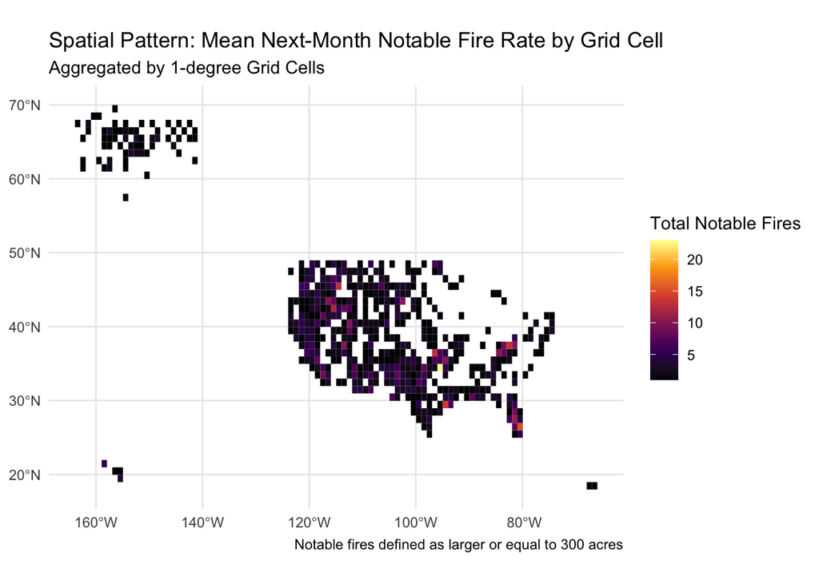

```r
# calculate total fire freuqence per grid cell
spatial_counts <- fires_with_grid %>%
  st_drop_geometry() %>%
  group_by(grid_id) %>%
  summarise(total_fires = n(), .group = "drop")

# join the counts back to the spatial grid object
spatial_grid_plot <- grid %>%
  left_join(spatial_counts, by = "grid_id") %>%
  mutate(total_fires = replace_na(total_fires, 0))

# filter out NAs to make the background cleaner
eda_spatial <- spatial_grid_plot %>%
  filter(total_fires > 0)

ggplot(data = eda_spatial) +
  geom_sf(aes(fill = total_fires), color = NA) +
  scale_fill_viridis_c(option = "inferno", name = "Total Notable Fires") +
  labs(title = "Spatial Pattern: Mean Next-Month Notable Fire Rate by Grid Cell",
       subtitle = "Aggregated by 1-degree Grid Cells",
       caption = "Notable fires defined as larger or equal to 300 acres") +
  theme_minimal()
```

### EDA Plot: Temporal patterns

To examine seasonality, we computed the **mean next-month fire probability** for each calendar month—that is, the proportion of grid cells that experienced a notable fire in the following month, averaged across all years and grid cells.

The bar chart reveals a strong and clear **seasonal pattern** in wildfire activity:

This strong seasonality directly motivates the use of **cyclical month encodings** (`month_sin`, `month_cos`) as predictors, rather than treating month as a linear or categorical variable. The pattern confirms that the time of year is a meaningful signal for predicting near-future wildfire occurrence.

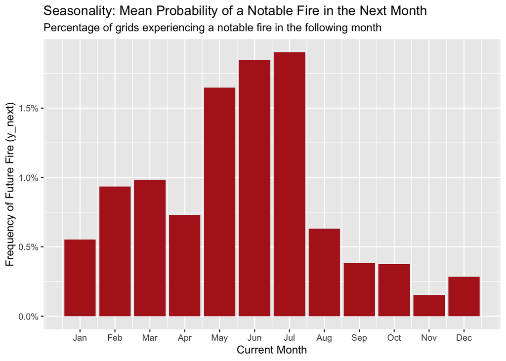

```r
# ensure the data frame has State, Seasonal, and Lag features
modeling_ready <- final_modeling_data %>%
  arrange(grid_id, YEAR, MONTH) %>%
  group_by(grid_id) %>%
  mutate(y_next = lead(fire_occurred, n = 1)) %>% # n = 1 is for bringing the future back to the present row
  filter(!is.na(y_next)) %>% # remove the last month of 2015 so the code doesn't run into a dead end for 2016
  ungroup()

# custom temporal pattern code
eda_temporal <- modeling_set %>%
  group_by(MONTH) %>%
  summarise(risk_level = mean(y_next), .groups = "drop")

ggplot(eda_temporal, aes(x = MONTH, y = risk_level)) +
  geom_col(fill = "firebrick") +
  scale_x_continuous(breaks = 1:12, labels = month.abb) +
  scale_y_continuous(labels = scales::percent) +
  labs(title = "Seasonality: Mean Probability of a Notable Fire in the Next Month",
       subtitle = "Percentage of grids experiencing a notable fire in the following month",
       x = "Current Month",
       y = "Frequency of Future Fire (y_next)")
```

## 3. Modeling

#### Data preparation

The final `panel` was constructed by:

1. Joining `fire_sizes` (average burned area per grid cell and month) to `modeling_ready`
2. Replacing missing `avg_size` values with 0 for grid-month combinations with no fires
3. Recalculating `size_roll3` and `size_roll12` within the same pipeline to avoid variable scoping issues in R
4. Converting `y_next` to a factor with levels `{0, 1}` for binary classification
5. Removing rows where `y_next` is missing (i.e., the final month of each grid cell’s history)

The verified panel contains 149527 observations, with 149527 non-missing `avg_size` values, confirming the join was successful.

```r
# this is where it gets extremely bizarre: `size_roll3` and `size_roll12` are in the data frame modeling_ready but R couldn't find them
# so I had to rebuild the code from scratch and put it in one chunk so it wouldn't be confused
# this fire_sizes with YEAR and MONTH from fires object
fire_sizes <- fires %>%
  filter(FIRE_SIZE >= 300) %>%
  filter(!is.na(LATITUDE) & !is.na(LONGITUDE)) %>%
  st_as_sf(coords = c("LONGITUDE", "LATITUDE"), crs = 4326) %>%
  st_join(grid) %>%
  st_drop_geometry() %>%
  group_by(grid_id, YEAR, MONTH) %>%
  summarise(avg_size = mean(FIRE_SIZE), .groups = "drop")

# and this panel with everything calculated inside so R would not lose them
panel <- modeling_ready %>%
  left_join(fire_sizes, by = c("grid_id", "YEAR", "MONTH")) %>%
  mutate(avg_size = replace_na(avg_size, 0)) %>%
  mutate(y_next = factor(y_next, levels = c(0, 1))) %>%
  filter(!is.na(y_next)) %>%
  arrange(grid_id, YEAR, MONTH) %>%
  group_by(grid_id) %>%
  mutate(
    size_roll3  = roll_sum(avg_size, n = 3,  align = "right", fill = 0), # recalculate the size_rolls because said reason
    size_roll12 = roll_sum(avg_size, n = 12, align = "right", fill = 0)
  ) %>%
  ungroup()

# Verify
colnames(panel)
```

```
##  [1] "grid_id"       "YEAR"          "MONTH"         "fire_occurred"
##  [5] "state"         "month_sin"     "month_cos"     "fire_lag12"
##  [9] "fire_roll3"    "fire_roll12"   "y_next"        "avg_size"
## [13] "size_roll3"    "size_roll12"
```

```r
sum(!is.na(panel$avg_size))
```

```
## [1] 149527
```

```r
train_df <- panel %>% filter(YEAR <= 2010)
test_df  <- panel %>% filter(YEAR > 2010)

baseline_model <- glm(
  y_next ~ state + month_sin + month_cos +
           fire_lag12 + fire_roll3 + fire_roll12 +
           size_roll3 + size_roll12,
  data   = train_df,
  family = binomial
)

summary(baseline_model)
```

```
##
## Call:
## glm(formula = y_next ~ state + month_sin + month_cos + fire_lag12 +
##     fire_roll3 + fire_roll12 + size_roll3 + size_roll12, family = binomial,
##     data = train_df)
##
## Coefficients:
##               Estimate Std. Error z value Pr(>|z|)
## (Intercept) -5.637e+00  1.334e-01 -42.267  < 2e-16 ***
## stateAL      4.454e-01  2.911e-01   1.530 0.125965
## stateAR      6.800e-02  5.939e-01   0.114 0.908845
## stateAZ      7.290e-01  2.025e-01   3.600 0.000318 ***
## stateCA      8.911e-01  1.689e-01   5.277 1.31e-07 ***
## stateCO      4.645e-01  2.285e-01   2.033 0.042048 *
## stateFL      1.230e+00  1.857e-01   6.622 3.53e-11 ***
## stateGA      2.656e-01  4.680e-01   0.568 0.570326
## stateHI      8.201e-01  3.609e-01   2.273 0.023053 *
## stateIA      5.403e-02  7.215e-01   0.075 0.940305
## stateID      1.115e+00  1.809e-01   6.164 7.08e-10 ***
## stateIN      5.258e-02  1.012e+00   0.052 0.958553
## stateKS      1.510e-01  3.300e-01   0.458 0.647175
## stateKY      1.546e+00  2.280e-01   6.782 1.19e-11 ***
## stateLA      7.995e-01  3.312e-01   2.414 0.015774 *
## stateMD      6.182e-02  7.214e-01   0.086 0.931710
## stateMI     -3.419e-01  7.207e-01  -0.474 0.635188
## stateMN      9.490e-01  2.854e-01   3.325 0.000883 ***
## stateMO      3.591e-01  3.303e-01   1.087 0.277024
## stateMS      6.515e-01  2.776e-01   2.347 0.018910 *
## stateMT      5.787e-01  1.961e-01   2.952 0.003161 **
## stateNC      3.259e-01  5.193e-01   0.628 0.530198
## stateND     -3.439e-01  5.181e-01  -0.664 0.506838
## stateNE     -2.888e-01  4.011e-01  -0.720 0.471529
## stateNJ      2.722e-01  4.680e-01   0.582 0.560726
## stateNM      8.162e-01  1.832e-01   4.455 8.38e-06 ***
## stateNV      8.028e-01  2.013e-01   3.987 6.69e-05 ***
## stateNY      6.825e-02  1.012e+00   0.067 0.946216
## stateOK      1.385e+00  1.874e-01   7.391 1.46e-13 ***
## stateOR      6.359e-01  2.066e-01   3.078 0.002084 **
## statePA      5.275e-02  5.940e-01   0.089 0.929238
## statePR      4.932e-02  7.215e-01   0.068 0.945502
```

[output cut: 13 more lines]

```
## fire_roll3   5.271e-01  1.468e-01   3.591 0.000329 ***
## fire_roll12  3.474e-01  8.622e-02   4.030 5.59e-05 ***
## size_roll3  -1.732e-05  2.460e-05  -0.704 0.481361
## size_roll12 -6.804e-06  9.923e-06  -0.686 0.492875
## ---
## Signif. codes:  0 '***' 0.001 '**' 0.01 '*' 0.05 '.' 0.1 ' ' 1
##
## (Dispersion parameter for binomial family taken to be 1)
##
##     Null deviance: 11362  on 112535  degrees of freedom
## Residual deviance: 10755  on 112487  degrees of freedom
##   (6252 observations deleted due to missingness)
## AIC: 10853
##
## Number of Fisher Scoring iterations: 8
```

#### Baseline model: Logistic regression

A logistic regression model was fitted as the baseline, using state, cyclical month encodings, fire history lags, and rolling fire size as predictors:

$$\log\frac{p}{1-p} = \beta_0 + \beta_1
\text{state} + \beta_2 \text{month_sin} + \beta_3 \text{month_cos} +
\beta_4 \text{fire_lag12} + \beta_5 \text{fire_roll3} + \beta_6
\text{fire_roll12} + \beta_7 \text{size_roll3} + \beta_8
\text{size_roll12}$$

The model was trained on years $\le$ 2010 and evaluated on years $>$ 2010. Predictions were thresholded at 0.5 to produce binary class labels.

**Confusion matrix (test set) is as below:**

```r
# evaluate the baseline on the test set
test_df$pred_prob <- predict(baseline_model, newdata = test_df, type = "response")
test_df$pred_class <- ifelse(test_df$pred_prob > 0.5, 1, 0)

# confusion matrix + accuracy
table(Predicted = test_df$pred_class, Actual = test_df$y_next)
```

```
##          Actual
## Predicted     0     1
##         0 30454   285
```

```r
mean(test_df$pred_class == as.numeric(as.character(test_df$y_next)))
```

```
## [1] 0.9907284
```

The model achieved an overall accuracy of **99.07%**, but this is misleading—it predicts **every observation as non-fire**, correctly classifying the majority class while completely failing to detect any actual fire events. This is a direct consequence of the severe class imbalance (~99:1), and highlights that **accuracy alone is an inappropriate metric** for this prediction task.

#### Model of choice: Balanced Random Forest

A **Random Forest** was chosen as the second model due to its ability to capture non-linear relationships between predictors and fire occurrence, and its robustness to the class imbalance problem that undermined the baseline logistic regression.

To address the severe class imbalance (~99:1), the model was trained using **balanced stratified sampling**, drawing 500 observations from each class per tree (`sampsize = c("0" = 500, "1" = 500)`). This forces each tree to learn from an equal number of fire and non-fire observations. The forest was built with 100 trees (`ntree = 100`) and a minimum node size of 10 (`nodesize = 10`) to speed up computation.

**Confusion matrix (test set) is as below:**

```r
# The second model is Random Forest because I have learned about it
train_clean <- train_df %>%
  select(y_next, state, month_sin, month_cos,
         fire_lag12, fire_roll3, fire_roll12,
         size_roll3, size_roll12) %>%
  na.omit()

test_clean <- test_df %>%
  select(y_next, state, month_sin, month_cos,
         fire_lag12, fire_roll3, fire_roll12,
         size_roll3, size_roll12) %>%
  na.omit()

rf_model <- randomForest(
  y_next ~ state + month_sin + month_cos +
           fire_lag12 + fire_roll3 + fire_roll12 +
           size_roll3 + size_roll12,
  data = train_clean,
  ntree = 100,
  sampsize = c("0" = 500, "1" = 500),
  strata = train_clean$y_next,
  nodesize = 10
)

test_clean$rf_pred <- predict(rf_model, newdata = test_clean)
table(Predicted = test_clean$rf_pred, Actual = test_clean$y_next)
```

```
##          Actual
## Predicted     0     1
##         0 20337    90
##         1 10117   195
```

```r
mean(test_clean$rf_pred == test_clean$y_next)
```

```
## [1] 0.6679463
```

## 4. Model Fitting and Validation

### Validation strategy: Walk-forward expanding window

To respect the temporal structure of the data and prevent data leakage, both models were evaluated using a **walk-forward expanding window** validation scheme. For each fold $t$:

- **Train** on all observations from years $\le t$
- **Validate** on observations from year $t +1$ only

This ensures the model is always trained on past data and tested on future data, mimicking real-world deployment conditions. Validation begins at year $t \ge min(year) + 2$ to ensure a sufficient training window for early folds.

A total of 21 validation folds were evaluated, spanning years 1995 to 2015.

### Logistic regression: Walk-forward AUC

At each fold, a fresh logistic regression was fitted on the training window and evaluated on the held-out year. To prevent prediction errors caused by unseen state factor levels in early training folds, all state levels were set upfront using the full panel before the loop. A `tryCatch()` wrapper was used to gracefully handle any remaining errors and log skipped years without interrupting the loop.

Performance was measured using the **Area Under the ROC Curve (AUC)**, which is more appropriate than accuracy for this severely imbalanced classification problem. An AUC of 0.5 corresponds to random guessing, while 1.0 indicates perfect discrimination.

```r
# First, set all state levels upfront
all_states <- unique(panel$state)
years <- sort(unique(panel$YEAR))
walk_forward_years <- years[years > min(years) + 2]

glm_auc_results <- data.frame(year = integer(), auc = numeric())

for (test_year in walk_forward_years) {
  train_fold <- panel %>% filter(YEAR < test_year) %>% na.omit()
  test_fold <- panel %>% filter(YEAR == test_year) %>% na.omit()

  if (nrow(test_fold) == 0 || sum(test_fold$y_next == 1) == 0) next

  # Fix: ensure both folds share the same factor levels
  train_fold$state <- factor(train_fold$state, levels = all_states)
  test_fold$state <- factor(test_fold$state,  levels = all_states)

  tryCatch({  # wrap in tryCatch to catch any remaining errors
    fold_glm <- glm(
      y_next ~ state + month_sin + month_cos +
               fire_lag12 + fire_roll3 + fire_roll12 +
               size_roll3 + size_roll12,
      data   = train_fold,
      family = binomial
    )

    probs <- predict(fold_glm, newdata = test_fold, type = "response")
    auc_val <- auc(roc(as.numeric(as.character(test_fold$y_next)), probs, quiet = TRUE))
    glm_auc_results <- rbind(glm_auc_results, data.frame(year = test_year, auc = as.numeric(auc_val)))

  }, error = function(e) {
    cat("Skipped year", test_year, "- Error:", conditionMessage(e), "\n")
  })
}

print(glm_auc_results)
```

```
##    year       auc
## 1  1995 0.6604590
## 2  1996 0.7145858
## 3  1997 0.7565096
## 4  1998 0.7426021
## 5  1999 0.6664783
## 6  2000 0.7031175
## 7  2001 0.7514633
## 8  2002 0.7203635
## 9  2003 0.7050498
## 10 2004 0.6741471
## 11 2005 0.6539293
## 12 2006 0.6675201
## 13 2007 0.6391966
## 14 2008 0.6107161
## 15 2009 0.6698831
## 16 2010 0.6541802
## 17 2011 0.6582484
## 18 2012 0.6549154
## 19 2013 0.7141293
## 20 2014 0.7352372
## 21 2015 0.6922874
```

### Random Forest: Walk-forward AUC

The same walk-forward expanding window scheme was applied to the balanced Random Forest. At each fold, a fresh forest was trained on the expanding training window using **balanced stratified sampling** to address class imbalance.

The sample size per class was capped at `min(500, n_minority)` to handle early folds where the number of fire observations in the training window may be smaller than 500. This ensures the model always trains on equal numbers of fire and non-fire observations without oversampling beyond what is available.

Predicted probabilities for the fire class were extracted using `type = "prob"` and used to compute the AUC, rather than hard class predictions which gives a more nuanced measure of model discrimination ability that is not sensitive to the 0.5 classification threshold.

```r
# RF walk-fowards
rf_auc_results <- data.frame(year = integer(), auc = numeric())

for (test_year in walk_forward_years) {
  train_fold <- panel %>% filter(YEAR < test_year) %>%
    select(y_next, state, month_sin, month_cos,
           fire_lag12, fire_roll3, fire_roll12,
           size_roll3, size_roll12) %>% na.omit()

  test_fold <- panel %>% filter(YEAR == test_year) %>%
    select(y_next, state, month_sin, month_cos,
           fire_lag12, fire_roll3, fire_roll12,
           size_roll3, size_roll12) %>% na.omit()

  if (nrow(test_fold) == 0 || sum(test_fold$y_next == 1) == 0) next

  n_minority <- sum(train_fold$y_next == 1)
  sample_size <- min(500, n_minority)

  fold_rf <- randomForest(
    y_next ~ state + month_sin + month_cos +
      fire_lag12 + fire_roll3 + fire_roll12 +
      size_roll3 + size_roll12,
    data = train_fold,
    ntree = 100,
    sampsize = c("0" = sample_size, "1" = sample_size),
    strata = train_fold$y_next
  )
  probs <- predict(fold_rf, newdata = test_fold, type = "prob")[, "1"]
  auc_val <- auc(roc(as.numeric(as.character(test_fold$y_next)), probs, quiet = TRUE))
  rf_auc_results <- rbind(rf_auc_results, data.frame(year = test_year, auc = as.numeric(auc_val)))
}
print(rf_auc_results)
```

```
##    year       auc
## 1  1995 0.6960598
## 2  1996 0.7628434
## 3  1997 0.7508269
## 4  1998 0.8007744
## 5  1999 0.6744520
## 6  2000 0.7475787
## 7  2001 0.7947262
## 8  2002 0.7660229
## 9  2003 0.7962179
## 10 2004 0.7669783
## 11 2005 0.7384403
## 12 2006 0.7037232
## 13 2007 0.6786996
## 14 2008 0.6808461
## 15 2009 0.7111792
## 16 2010 0.7155291
## 17 2011 0.6930786
## 18 2012 0.7328605
## 19 2013 0.8056159
## 20 2014 0.7970086
## 21 2015 0.8279356
```

### Model comparison

[output not shown]

#### Diagnostic plot: AUC over validation years

Overall, the walk-forward validation confirms that the **Balanced Random Forest is the stronger model**, and that fire history and seasonality provide meaningful but imperfect predictive signal for near-future wildfire incidence.

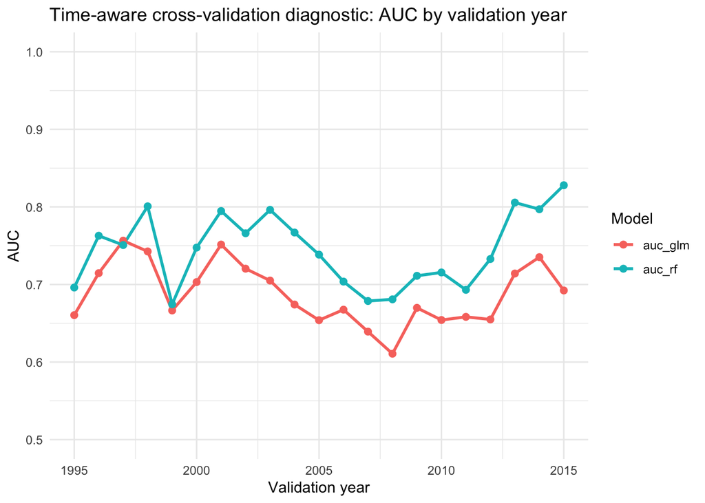

```r
auc_combined <- rbind(
  glm_auc_results %>% mutate(model = "auc_glm"),
  rf_auc_results %>% mutate(model = "auc_rf")
)

ggplot(auc_combined, aes(x = year, y = auc, color = model)) +
  geom_line(linewidth = 1) +
  geom_point(size = 2) +
  labs(
    title = "Time-aware cross-validation diagnostic: AUC by validation year",
    x = "Validation year",
    y = "AUC",
    color = "Model"
  ) +
  scale_y_continuous(limits = c(0.5, 1.0)) +
  theme_minimal()
```

## 5. Summary

### **Key findings from exploratory data analysis**

**Temporally**, wildfire risk follows a strong and predictable seasonal cycle. The probability of a notable fire in the following month peaks sharply in. **June and July (~1.8%)** and drops to near zero in **November and December**. A secondary spring peak in February–March likely reflects early-season fire activity in the southeastern states. This seasonal pattern is one of the strongest signals available for prediction.

### **What the models capture**

Both models were designed to predict whether a notable wildfire ($\ge$ 300 acres) would occur in a given $1^{\circ}$ by $1^{\circ}$ grid cell in the **following month**, using only information available at the time of prediction.

The **logistic regression baseline** captures linear relationships between fire risk and the predictors. While it achieves 99% accuracy on the test set, this is entirely due to the severe class imbalance and the model predicts no fires at all, making it operationally useless despite its high accuracy.

### **Practical interpretation**

The results suggest that **where and when fires have occurred in the past is a meaningful predictor of where and when they will occur in the future**. Grid cells with recent fire activity, located in historically fire-prone states, during summer months, are significantly more likely to experience a notable fire in the following month.

However, the year-to-year variability in model performance suggests that factors not captured in this dataset such as drought conditions, wind speed, and land cover likely play an important role in determining fire risk in any given year. Incorporating such external data sources would be a natural next step to improve predictive performance.